# Project: Wrangling and Analyze Data

```python
# check letter case for names
archive[archive.name.str.islower()].name.value_counts()
```

```
a               55
the              8
an               7
very             5
quite            4
just             4
one              4
actually         2
mad              2
getting          2
not              2
all              1
light            1
infuriating      1
old              1
officially       1
my               1
life             1
incredibly       1
unacceptable     1
such             1
by               1
this             1
his              1
space            1
Name: name, dtype: int64
```

Alot of the names are lower cases and some are not names at all.

```python
# check retweet tweets
archive.retweeted_status_user_id.count()
```

```
181
```

```python
# check names value count
archive['rating_numerator'].value_counts()[:20]
```

```
12     558
11     464
10     461
13     351
9      158
8      102
7       55
14      54
5       37
6       32
3       19
4       17
1        9
2        9
420      2
0        2
15       2
75       2
80       1
20       1
Name: rating_numerator, dtype: int64
```

12 is the most common rating_numerator, It has 558 value_counts

```python
archive['rating_denominator'].value_counts()
```

```
10     2333
11        3
50        3
80        2
20        2
2         1
16        1
40        1
70        1
15        1
90        1
110       1
120       1
130       1
150       1
170       1
7         1
0         1
Name: rating_denominator, dtype: int64
```

10 is the most common rating_denominator, it has 2333 value_counts

```python
# Check archive for any null numerator values
sum(archive.rating_numerator.isnull())
```

```
0
```

```python
# wrong typing for rate numerator
archive[archive['rating_numerator'] >15 ]
# archive[archive['rating_denominator'] >15 ]
```

|  | tweet_id | in_reply_to_status_id | in_reply_to_user_id | timestamp | source | text | retweeted_status_id | retweeted_status_user_id | retweeted_status_timestamp | expanded_urls | rating_numerator | rating_denominator | name | doggo | floofer | pupper | puppo | division |
| --- | --- | --- | --- | --- | --- | --- | --- | --- | --- | --- | --- | --- | --- | --- | --- | --- | --- | --- |
| 55 | 881633300179243008 | 8.816070e+17 | 4.738443e+07 | 2017-07-02 21:58:53 +0000 | <a href="http://twitter.com/download/iphone" r... | @roushfenway These are good dogs but 17/10 is ... | NaN | NaN | NaN | NaN | 17 | 10 | None | None | None | None | None | 1.700000 |
| 188 | 855862651834028034 | 8.558616e+17 | 1.943518e+08 | 2017-04-22 19:15:32 +0000 | <a href="http://twitter.com/download/iphone" r... | @dhmontgomery We also gave snoop dogg a 420/10... | NaN | NaN | NaN | NaN | 420 | 10 | None | None | None | None | None | 42.000000 |
| 189 | 855860136149123072 | 8.558585e+17 | 1.361572e+07 | 2017-04-22 19:05:32 +0000 | <a href="http://twitter.com/download/iphone" r... | @s8n You tried very hard to portray this good ... | NaN | NaN | NaN | NaN | 666 | 10 | None | None | None | None | None | 66.600000 |
| 290 | 838150277551247360 | 8.381455e+17 | 2.195506e+07 | 2017-03-04 22:12:52 +0000 | <a href="http://twitter.com/download/iphone" r... | @markhoppus 182/10 | NaN | NaN | NaN | NaN | 182 | 10 | None | None | None | None | None | 18.200000 |
| 313 | 835246439529840640 | 8.352460e+17 | 2.625958e+07 | 2017-02-24 21:54:03 +0000 | <a href="http://twitter.com/download/iphone" r... | @jonnysun @Lin_Manuel ok jomny I know you're e... | NaN | NaN | NaN | NaN | 960 | 0 | None | None | None | None | None | inf |
| 340 | 832215909146226688 | NaN | NaN | 2017-02-16 13:11:49 +0000 | <a href="http://twitter.com/download/iphone" r... | RT @dog_rates: This is Logan, the Chow who liv... | 7.867091e+17 | 4.196984e+09 | 2016-10-13 23:23:56 +0000 | https://twitter.com/dog_rates/status/786709082... | 75 | 10 | Logan | None | None | None | None | 7.500000 |
| 433 | 820690176645140481 | NaN | NaN | 2017-01-15 17:52:40 +0000 | <a href="http://twitter.com/download/iphone" r... | The floofs have been released I repeat the flo... | NaN | NaN | NaN | https://twitter.com/dog_rates/status/820690176... | 84 | 70 | None | None | None | None | None | 1.200000 |
| 516 | 810984652412424192 | NaN | NaN | 2016-12-19 23:06:23 +0000 | <a href="http://twitter.com/download/iphone" r... | Meet Sam. She smiles 24/7 &amp; secretly aspir... | NaN | NaN | NaN | https://www.gofundme.com/sams-smile,https://tw... | 24 | 7 | Sam | None | None | None | None | 3.428571 |
| 695 | 786709082849828864 | NaN | NaN | 2016-10-13 23:23:56 +0000 | <a href="http://twitter.com/download/iphone" r... | This is Logan, the Chow who lived. He solemnly... | NaN | NaN | NaN | https://twitter.com/dog_rates/status/786709082... | 75 | 10 | Logan | None | None | None | None | 7.500000 |
| 763 | 778027034220126208 | NaN | NaN | 2016-09-20 00:24:34 +0000 | <a href="http://twitter.com/download/iphone" r... | This is Sophie. She's a Jubilant Bush Pupper. ... | NaN | NaN | NaN | https://twitter.com/dog_rates/status/778027034... | 27 | 10 | Sophie | None | None | pupper | None | 2.700000 |
| 902 | 758467244762497024 | NaN | NaN | 2016-07-28 01:00:57 +0000 | <a href="http://twitter.com/download/iphone" r... | Why does this never happen at my front door...... | NaN | NaN | NaN | https://twitter.com/dog_rates/status/758467244... | 165 | 150 | None | None | None | None | None | 1.100000 |
| 979 | 749981277374128128 | NaN | NaN | 2016-07-04 15:00:45 +0000 | <a href="https://about.twitter.com/products/tw... | This is Atticus. He's quite simply America af.... | NaN | NaN | NaN | https://twitter.com/dog_rates/status/749981277... | 1776 | 10 | Atticus | None | None | None | None | 177.600000 |
| 1120 | 731156023742988288 | NaN | NaN | 2016-05-13 16:15:54 +0000 | <a href="http://twitter.com/download/iphone" r... | Say hello to this unbelievably well behaved sq... | NaN | NaN | NaN | https://twitter.com/dog_rates/status/731156023... | 204 | 170 | this | None | None | None | None | 1.200000 |
| 1202 | 716439118184652801 | NaN | NaN | 2016-04-03 01:36:11 +0000 | <a href="http://twitter.com/download/iphone" r... | This is Bluebert. He just saw that both #Final... | NaN | NaN | NaN | https://twitter.com/dog_rates/status/716439118... | 50 | 50 | Bluebert | None | None | None | None | 1.000000 |
| 1228 | 713900603437621249 | NaN | NaN | 2016-03-27 01:29:02 +0000 | <a href="http://twitter.com/download/iphone" r... | Happy Saturday here's 9 puppers on a bench. 99... | NaN | NaN | NaN | https://twitter.com/dog_rates/status/713900603... | 99 | 90 | None | None | None | None | None | 1.100000 |
| 1254 | 710658690886586372 | NaN | NaN | 2016-03-18 02:46:49 +0000 | <a href="http://twitter.com/download/iphone" r... | Here's a brigade of puppers. All look very pre... | NaN | NaN | NaN | https://twitter.com/dog_rates/status/710658690... | 80 | 80 | None | None | None | None | None | 1.000000 |
| 1274 | 709198395643068416 | NaN | NaN | 2016-03-14 02:04:08 +0000 | <a href="http://twitter.com/download/iphone" r... | From left to right:\nCletus, Jerome, Alejandro... | NaN | NaN | NaN | https://twitter.com/dog_rates/status/709198395... | 45 | 50 | None | None | None | None | None | 0.900000 |
| 1351 | 704054845121142784 | NaN | NaN | 2016-02-28 21:25:30 +0000 | <a href="http://twitter.com/download/iphone" r... | Here is a whole flock of puppers. 60/50 I'll ... | NaN | NaN | NaN | https://twitter.com/dog_rates/status/704054845... | 60 | 50 | a | None | None | None | None | 1.200000 |
| 1433 | 697463031882764288 | NaN | NaN | 2016-02-10 16:51:59 +0000 | <a href="http://twitter.com/download/iphone" r... | Happy Wednesday here's a bucket of pups. 44/40... | NaN | NaN | NaN | https://twitter.com/dog_rates/status/697463031... | 44 | 40 | None | None | None | None | None | 1.100000 |
| 1634 | 684225744407494656 | 6.842229e+17 | 4.196984e+09 | 2016-01-05 04:11:44 +0000 | <a href="http://twitter.com/download/iphone" r... | Two sneaky puppers were not initially seen, mo... | NaN | NaN | NaN | https://twitter.com/dog_rates/status/684225744... | 143 | 130 | None | None | None | None | None | 1.100000 |
| 1635 | 684222868335505415 | NaN | NaN | 2016-01-05 04:00:18 +0000 | <a href="http://twitter.com/download/iphone" r... | Someone help the girl is being mugged. Several... | NaN | NaN | NaN | https://twitter.com/dog_rates/status/684222868... | 121 | 110 | None | None | None | None | None | 1.100000 |
| 1663 | 682808988178739200 | 6.827884e+17 | 4.196984e+09 | 2016-01-01 06:22:03 +0000 | <a href="http://twitter.com/download/iphone" r... | I'm aware that I could've said 20/16, but here... | NaN | NaN | NaN | NaN | 20 | 16 | None | None | None | None | None | 1.250000 |
| 1712 | 680494726643068929 | NaN | NaN | 2015-12-25 21:06:00 +0000 | <a href="http://twitter.com/download/iphone" r... | Here we have uncovered an entire battalion of ... | NaN | NaN | NaN | https://twitter.com/dog_rates/status/680494726... | 26 | 10 | None | None | None | None | None | 2.600000 |
| 1779 | 677716515794329600 | NaN | NaN | 2015-12-18 05:06:23 +0000 | <a href="http://twitter.com/download/iphone" r... | IT'S PUPPERGEDDON. Total of 144/120 ...I think... | NaN | NaN | NaN | https://twitter.com/dog_rates/status/677716515... | 144 | 120 | None | None | None | None | None | 1.200000 |
| 1843 | 675853064436391936 | NaN | NaN | 2015-12-13 01:41:41 +0000 | <a href="http://twitter.com/download/iphone" r... | Here we have an entire platoon of puppers. Tot... | NaN | NaN | NaN | https://twitter.com/dog_rates/status/675853064... | 88 | 80 | None | None | None | None | None | 1.100000 |
| 2074 | 670842764863651840 | NaN | NaN | 2015-11-29 05:52:33 +0000 | <a href="http://twitter.com/download/iphone" r... | After so many requests... here you go.\n\nGood... | NaN | NaN | NaN | https://twitter.com/dog_rates/status/670842764... | 420 | 10 | None | None | None | None | None | 42.000000 |

```python
# Check archive for any null denominator values
sum(archive.rating_denominator.isnull())
```

```
0
```

```python
# wrong typing for rate denominator
archive[archive['rating_denominator'] >15 ]
```

|  | tweet_id | in_reply_to_status_id | in_reply_to_user_id | timestamp | source | text | retweeted_status_id | retweeted_status_user_id | retweeted_status_timestamp | expanded_urls | rating_numerator | rating_denominator | name | doggo | floofer | pupper | puppo | division |
| --- | --- | --- | --- | --- | --- | --- | --- | --- | --- | --- | --- | --- | --- | --- | --- | --- | --- | --- |
| 433 | 820690176645140481 | NaN | NaN | 2017-01-15 17:52:40 +0000 | <a href="http://twitter.com/download/iphone" r... | The floofs have been released I repeat the flo... | NaN | NaN | NaN | https://twitter.com/dog_rates/status/820690176... | 84 | 70 | None | None | None | None | None | 1.20 |
| 902 | 758467244762497024 | NaN | NaN | 2016-07-28 01:00:57 +0000 | <a href="http://twitter.com/download/iphone" r... | Why does this never happen at my front door...... | NaN | NaN | NaN | https://twitter.com/dog_rates/status/758467244... | 165 | 150 | None | None | None | None | None | 1.10 |
| 1120 | 731156023742988288 | NaN | NaN | 2016-05-13 16:15:54 +0000 | <a href="http://twitter.com/download/iphone" r... | Say hello to this unbelievably well behaved sq... | NaN | NaN | NaN | https://twitter.com/dog_rates/status/731156023... | 204 | 170 | this | None | None | None | None | 1.20 |
| 1165 | 722974582966214656 | NaN | NaN | 2016-04-21 02:25:47 +0000 | <a href="http://twitter.com/download/iphone" r... | Happy 4/20 from the squad! 13/10 for all https... | NaN | NaN | NaN | https://twitter.com/dog_rates/status/722974582... | 4 | 20 | None | None | None | None | None | 0.20 |
| 1202 | 716439118184652801 | NaN | NaN | 2016-04-03 01:36:11 +0000 | <a href="http://twitter.com/download/iphone" r... | This is Bluebert. He just saw that both #Final... | NaN | NaN | NaN | https://twitter.com/dog_rates/status/716439118... | 50 | 50 | Bluebert | None | None | None | None | 1.00 |
| 1228 | 713900603437621249 | NaN | NaN | 2016-03-27 01:29:02 +0000 | <a href="http://twitter.com/download/iphone" r... | Happy Saturday here's 9 puppers on a bench. 99... | NaN | NaN | NaN | https://twitter.com/dog_rates/status/713900603... | 99 | 90 | None | None | None | None | None | 1.10 |
| 1254 | 710658690886586372 | NaN | NaN | 2016-03-18 02:46:49 +0000 | <a href="http://twitter.com/download/iphone" r... | Here's a brigade of puppers. All look very pre... | NaN | NaN | NaN | https://twitter.com/dog_rates/status/710658690... | 80 | 80 | None | None | None | None | None | 1.00 |
| 1274 | 709198395643068416 | NaN | NaN | 2016-03-14 02:04:08 +0000 | <a href="http://twitter.com/download/iphone" r... | From left to right:\nCletus, Jerome, Alejandro... | NaN | NaN | NaN | https://twitter.com/dog_rates/status/709198395... | 45 | 50 | None | None | None | None | None | 0.90 |
| 1351 | 704054845121142784 | NaN | NaN | 2016-02-28 21:25:30 +0000 | <a href="http://twitter.com/download/iphone" r... | Here is a whole flock of puppers. 60/50 I'll ... | NaN | NaN | NaN | https://twitter.com/dog_rates/status/704054845... | 60 | 50 | a | None | None | None | None | 1.20 |
| 1433 | 697463031882764288 | NaN | NaN | 2016-02-10 16:51:59 +0000 | <a href="http://twitter.com/download/iphone" r... | Happy Wednesday here's a bucket of pups. 44/40... | NaN | NaN | NaN | https://twitter.com/dog_rates/status/697463031... | 44 | 40 | None | None | None | None | None | 1.10 |
| 1598 | 686035780142297088 | 6.860340e+17 | 4.196984e+09 | 2016-01-10 04:04:10 +0000 | <a href="http://twitter.com/download/iphone" r... | Yes I do realize a rating of 4/20 would've bee... | NaN | NaN | NaN | NaN | 4 | 20 | None | None | None | None | None | 0.20 |
| 1634 | 684225744407494656 | 6.842229e+17 | 4.196984e+09 | 2016-01-05 04:11:44 +0000 | <a href="http://twitter.com/download/iphone" r... | Two sneaky puppers were not initially seen, mo... | NaN | NaN | NaN | https://twitter.com/dog_rates/status/684225744... | 143 | 130 | None | None | None | None | None | 1.10 |
| 1635 | 684222868335505415 | NaN | NaN | 2016-01-05 04:00:18 +0000 | <a href="http://twitter.com/download/iphone" r... | Someone help the girl is being mugged. Several... | NaN | NaN | NaN | https://twitter.com/dog_rates/status/684222868... | 121 | 110 | None | None | None | None | None | 1.10 |
| 1663 | 682808988178739200 | 6.827884e+17 | 4.196984e+09 | 2016-01-01 06:22:03 +0000 | <a href="http://twitter.com/download/iphone" r... | I'm aware that I could've said 20/16, but here... | NaN | NaN | NaN | NaN | 20 | 16 | None | None | None | None | None | 1.25 |
| 1779 | 677716515794329600 | NaN | NaN | 2015-12-18 05:06:23 +0000 | <a href="http://twitter.com/download/iphone" r... | IT'S PUPPERGEDDON. Total of 144/120 ...I think... | NaN | NaN | NaN | https://twitter.com/dog_rates/status/677716515... | 144 | 120 | None | None | None | None | None | 1.20 |
| 1843 | 675853064436391936 | NaN | NaN | 2015-12-13 01:41:41 +0000 | <a href="http://twitter.com/download/iphone" r... | Here we have an entire platoon of puppers. Tot... | NaN | NaN | NaN | https://twitter.com/dog_rates/status/675853064... | 88 | 80 | None | None | None | None | None | 1.10 |

```python
# view name text
print(archive['text'][100])
print(archive['name'][12])
```

```
Here are my favorite #dogsatpollingstations
Most voted for a more consistent walking schedule and to increase daily pats tenfold. All 13/10 https://t.co/17FVMl4VZ5
None
```

```python
# check for None in the 4 dog categories
archive[['doggo', 'floofer', 'pupper', 'puppo']][:15]
```

|  | doggo | floofer | pupper | puppo |
| --- | --- | --- | --- | --- |
| 0 | None | None | None | None |
| 1 | None | None | None | None |
| 2 | None | None | None | None |
| 3 | None | None | None | None |
| 4 | None | None | None | None |
| 5 | None | None | None | None |
| 6 | None | None | None | None |
| 7 | None | None | None | None |
| 8 | None | None | None | None |
| 9 | doggo | None | None | None |
| 10 | None | None | None | None |
| 11 | None | None | None | None |
| 12 | None | None | None | puppo |
| 13 | None | None | None | None |
| 14 | None | None | None | puppo |

These dogs development categories have 'None' when it should be 'NaN'.

## image_preds

```python
# view info
image_preds.info()
```

```
<class 'pandas.core.frame.DataFrame'>
RangeIndex: 2075 entries, 0 to 2074
Data columns (total 12 columns):
tweet_id    2075 non-null int64
jpg_url     2075 non-null object
img_num     2075 non-null int64
p1          2075 non-null object
p1_conf     2075 non-null float64
p1_dog      2075 non-null bool
p2          2075 non-null object
p2_conf     2075 non-null float64
p2_dog      2075 non-null bool
p3          2075 non-null object
p3_conf     2075 non-null float64
p3_dog      2075 non-null bool
dtypes: bool(3), float64(3), int64(2), object(4)
memory usage: 152.1+ KB
```

```python
# check p1_dog value count
image_preds['p1_dog'].value_counts()
```

```
True     1532
False     543
Name: p1_dog, dtype: int64
```

```python
# check some p2 samples
image_preds['p2'].sample(12)
# image_preds['p1'].sample(12)
# image_preds['p3'].sample(12)
```

```
2035                          malinois
768     American_Staffordshire_terrier
1115                    Great_Pyrenees
594                            meerkat
1778          Chesapeake_Bay_retriever
92                    miniature_poodle
1840                Labrador_retriever
93                           spotlight
1719                   German_shepherd
2027                Labrador_retriever
384                  Italian_greyhound
1277                             teddy
Name: p2, dtype: object
```

The dog breed name values in p1, p2, p3 columns are not consistently stored. The values capitalization is not uniform and underscores are used instead of spaces for readability.

```python
# view the shape
image_preds.shape
```

```
(2075, 12)
```

```python
# check the stastistics
image_preds.describe()
```

|  | tweet_id | img_num | p1_conf | p2_conf | p3_conf |
| --- | --- | --- | --- | --- | --- |
| count | 2.075000e+03 | 2075.000000 | 2075.000000 | 2.075000e+03 | 2.075000e+03 |
| mean | 7.384514e+17 | 1.203855 | 0.594548 | 1.345886e-01 | 6.032417e-02 |
| std | 6.785203e+16 | 0.561875 | 0.271174 | 1.006657e-01 | 5.090593e-02 |
| min | 6.660209e+17 | 1.000000 | 0.044333 | 1.011300e-08 | 1.740170e-10 |
| 25% | 6.764835e+17 | 1.000000 | 0.364412 | 5.388625e-02 | 1.622240e-02 |
| 50% | 7.119988e+17 | 1.000000 | 0.588230 | 1.181810e-01 | 4.944380e-02 |
| 75% | 7.932034e+17 | 1.000000 | 0.843855 | 1.955655e-01 | 9.180755e-02 |
| max | 8.924206e+17 | 4.000000 | 1.000000 | 4.880140e-01 | 2.734190e-01 |

```python
# check for duplicates
image_preds.duplicated().sum()
```

```
0
```

```python
# check jpg_url value count
image_preds['jpg_url'].value_counts()
```

```
https://pbs.twimg.com/media/Cx5R8wPVEAALa9r.jpg                                            2
https://pbs.twimg.com/media/CsGnz64WYAEIDHJ.jpg                                            2
https://pbs.twimg.com/media/CiibOMzUYAA9Mxz.jpg                                            2
https://pbs.twimg.com/media/CV_cnjHWUAADc-c.jpg                                            2
https://pbs.twimg.com/media/Ct72q9jWcAAhlnw.jpg                                            2
https://pbs.twimg.com/media/Cwx99rpW8AMk_Ie.jpg                                            2
https://pbs.twimg.com/media/CYLDikFWEAAIy1y.jpg                                            2
https://pbs.twimg.com/media/DA7iHL5U0AA1OQo.jpg                                            2
https://pbs.twimg.com/media/CtzKC7zXEAALfSo.jpg                                            2
https://pbs.twimg.com/media/C4bTH6nWMAAX_bJ.jpg                                            2
https://pbs.twimg.com/media/CpmyNumW8AAAJGj.jpg                                            2
https://pbs.twimg.com/media/Crwxb5yWgAAX5P_.jpg                                            2
https://pbs.twimg.com/media/CsVO7ljW8AAckRD.jpg                                            2
https://pbs.twimg.com/ext_tw_video_thumb/815965888126062592/pu/img/JleSw4wRhgKDWQj5.jpg    2
https://pbs.twimg.com/media/CU1zsMSUAAAS0qW.jpg                                            2
https://pbs.twimg.com/media/CWza7kpWcAAdYLc.jpg                                            2
https://pbs.twimg.com/media/C4KHj-nWQAA3poV.jpg                                            2
https://pbs.twimg.com/media/CwJR1okWIAA6XMp.jpg                                            2
https://pbs.twimg.com/media/Cveg1-NXgAASaaT.jpg                                            2
https://pbs.twimg.com/media/CtVAvX-WIAAcGTf.jpg                                            2
https://pbs.twimg.com/media/CU3mITUWIAAfyQS.jpg                                            2
https://pbs.twimg.com/media/CtKHLuCWYAA2TTs.jpg                                            2
https://pbs.twimg.com/media/CZhn-QAWwAASQan.jpg                                            2
https://pbs.twimg.com/media/CvyVxQRWEAAdSZS.jpg                                            2
https://pbs.twimg.com/media/C12whDoVEAALRxa.jpg                                            2
https://pbs.twimg.com/media/CcG07BYW0AErrC9.jpg                                            2
https://pbs.twimg.com/media/CkNjahBXAAQ2kWo.jpg                                            2
https://pbs.twimg.com/ext_tw_video_thumb/807106774843039744/pu/img/8XZg1xW35Xp2J6JW.jpg    2
https://pbs.twimg.com/media/CwS4aqZXUAAe3IO.jpg                                            2
https://pbs.twimg.com/tweet_video_thumb/CeBym7oXEAEWbEg.jpg                                2
                                                                                          ..
https://pbs.twimg.com/media/ClzoJz7WYAELHSf.jpg                                            1
https://pbs.twimg.com/media/CT5Vg_wXIAAXfnj.jpg                                            1
https://pbs.twimg.com/media/C3XvqILXUAU2nnT.jpg                                            1
https://pbs.twimg.com/media/ChfXDrGUkAEAtF-.jpg                                            1
https://pbs.twimg.com/media/Ca0lzzmWwAA5u56.jpg                                            1
https://pbs.twimg.com/media/C17n1nrWQAIErU3.jpg                                            1
https://pbs.twimg.com/media/CdyE2x1W8AAe0TG.jpg                                            1
https://pbs.twimg.com/media/C33P8PrUcAMiQQs.jpg                                            1
https://pbs.twimg.com/media/CooZok_WEAA7oPw.jpg                                            1
https://pbs.twimg.com/media/CdNOb17WwAA5z4A.jpg                                            1
https://pbs.twimg.com/media/CT42GRgUYAA5iDo.jpg                                            1
https://pbs.twimg.com/media/CUd2ieCUcAAexyT.jpg                                            1
https://pbs.twimg.com/media/DBP1asiUAAEKZI5.jpg                                            1
https://pbs.twimg.com/media/CXVBtX_WwAEuqbP.jpg                                            1
https://pbs.twimg.com/media/CU7nSZEW4AA6r5u.jpg                                            1
https://pbs.twimg.com/ext_tw_video_thumb/755110610942169088/pu/img/3-INz45pSRMkzOEF.jpg    1
https://pbs.twimg.com/media/CWe7kw9W4AE8UJh.jpg                                            1
https://pbs.twimg.com/media/DEfjEaNXkAAtPlj.jpg                                            1
https://pbs.twimg.com/ext_tw_video_thumb/803638023904559104/pu/img/vxm0Htm5iIV7EOAQ.jpg    1
https://pbs.twimg.com/media/CsB-MYiXgAEQU20.jpg                                            1
https://pbs.twimg.com/media/DE8yicJW0AAAvBJ.jpg                                            1
https://pbs.twimg.com/media/Cr2GNdlW8AAbojw.jpg                                            1
https://pbs.twimg.com/media/CZskaEIWIAUeTr5.jpg                                            1
https://pbs.twimg.com/media/CWxDaXHWsAAWV8W.jpg                                            1
https://pbs.twimg.com/media/C8XbDR1WAAAxND8.jpg                                            1
https://pbs.twimg.com/media/CUHr8WbWEAEBPgf.jpg                                            1
https://pbs.twimg.com/media/CUoZqaqWcAAA2MQ.jpg                                            1
https://pbs.twimg.com/media/CUNE_OSUwAAdHhX.jpg                                            1
https://pbs.twimg.com/media/CtZtJxAXEAAyPGd.jpg                                            1
https://pbs.twimg.com/media/CXV1Ot_W8AEpkQO.jpg                                            1
Name: jpg_url, Length: 2009, dtype: int64
```

```python
# check for columns with missing value
image_preds.isnull().sum().any()
```

```
False
```

```python
# check for rows with missing value
image_preds.isna().any(axis=1).sum()
```

```
0
```

```python
# check for duplicated jpg_url
image_preds['jpg_url'].duplicated().sum()
```

```
66
```

```python
# check for duplicate tweet_id
image_preds['tweet_id'].duplicated().sum()
```

```
0
```

```python
# check for null values
image_preds['jpg_url'].isnull().sum()
```

```
0
```

```python
# check for rowss with missing value
image_preds['jpg_url'].isna().any().sum()
```

```
0
```

```python
# check for p2_dog value count
image_preds['p2_dog'].value_counts()
```

```
True     1553
False     522
Name: p2_dog, dtype: int64
```

```python
# check for p3_dog value count
image_preds['p3_dog'].value_counts()
```

```
True     1499
False     576
Name: p3_dog, dtype: int64
```

p1_dog, p2_dog and p3_dog has alot of false values which are not actually dogs

## jason_tweet

```python
# view json table
json_tweet.head(6)
```

|  | tweet_id | favorite_count | retweet_count | user_favourites | user_followers | created_at | retweeted_status |
| --- | --- | --- | --- | --- | --- | --- | --- |
| 0 | 892420643555336193 | 33652 | 6956 | 147692 | 9370148 | Tue Aug 01 16:23:56 +0000 2017 | Original_tweet |
| 1 | 892177421306343426 | 29191 | 5263 | 147692 | 9370148 | Tue Aug 01 00:17:27 +0000 2017 | Original_tweet |
| 2 | 891815181378084864 | 21954 | 3463 | 147692 | 9370148 | Mon Jul 31 00:18:03 +0000 2017 | Original_tweet |
| 3 | 891689557279858688 | 36732 | 7182 | 147692 | 9370148 | Sun Jul 30 15:58:51 +0000 2017 | Original_tweet |
| 4 | 891327558926688256 | 35136 | 7707 | 147692 | 9370148 | Sat Jul 29 16:00:24 +0000 2017 | Original_tweet |
| 5 | 891087950875897856 | 17720 | 2582 | 147692 | 9370148 | Sat Jul 29 00:08:17 +0000 2017 | Original_tweet |

```python
# count retweeted tweets
json_tweet['retweeted_status'].count()
```

```
2327
```

```python
# check for null values in retweeted tweets
json_tweet['retweeted_status'].isnull().sum()
```

```
0
```

```python
# view the statistics of json
json_tweet.describe()
```

|  | favorite_count | retweet_count | user_favourites | user_followers |
| --- | --- | --- | --- | --- |
| count | 2327.000000 | 2327.000000 | 2327.000000 | 2.327000e+03 |
| mean | 7017.349377 | 2454.841427 | 147692.029222 | 9.370182e+06 |
| std | 10903.848292 | 4156.770955 | 0.340712 | 5.768679e+01 |
| min | 0.000000 | 1.000000 | 147692.000000 | 9.370148e+06 |
| 25% | 1218.000000 | 491.500000 | 147692.000000 | 9.370155e+06 |
| 50% | 3034.000000 | 1143.000000 | 147692.000000 | 9.370178e+06 |
| 75% | 8554.500000 | 2841.500000 | 147692.000000 | 9.370207e+06 |
| max | 144005.000000 | 70182.000000 | 147696.000000 | 9.370670e+06 |

```python
# check for the info
json_tweet.info()
```

```
<class 'pandas.core.frame.DataFrame'>
RangeIndex: 2327 entries, 0 to 2326
Data columns (total 7 columns):
tweet_id            2327 non-null object
favorite_count      2327 non-null int64
retweet_count       2327 non-null int64
user_favourites     2327 non-null int64
user_followers      2327 non-null int64
created_at          2327 non-null object
retweeted_status    2327 non-null object
dtypes: int64(4), object(3)
memory usage: 127.3+ KB
```

### Quality issues(Completeness, accuracy, consistency, validity)

### archive

2.Remove the string starting 'https' in text column.

3.retweeted_status_timestamp, timestamp should be datetime instead of string

4.Create 3 columns day,month ,year and change their datatype

5.Drop timestamp column

6.Remove retweets by deleting rows with non-null values in retweeted_status_id column

### image_preds

7.The column names such as p1,p2 are not descriptive, lets make it understandable

8.The dog breed name values in the p1, p2, and p3 columns are not consistent and capitalize first letters of dog predictions p1, p2, p3

9.Remove duplicate jpg_url entries as not to affect our analysis

10.False predictions, predictions contain other than dog animals.

### json_tweet

11.Delete columns that won't be used for analysis

13.Convert data type of tweet_id in all tables to object string data type for merging

14.Drop unusual columns we will not use in analysis

### archive

1.The 4 dog development categories should be combined to make a single categorical column.

### All Data

2.Merge archive, image_preds and json_tweet tables

## Cleaning Data

```python
# Make copies of original pieces of data
clean_arch = archive.copy()
clean_image = image_preds.copy()
clean_json = json_tweet.copy()
```

### Quality issues #1: archive

#### Code

```python
#drop 'a'
for x in clean_arch['name']:
    if x == "a":
        clean_arch.name = clean_arch.name.replace('a',np.nan)
```

```python
# change 'None' to be NaN, np.nan
clean_arch['name'] = clean_arch['name'].replace('None', np.nan)
#change all name first Capital letter
clean_arch['name'] = clean_arch['name'].str.capitalize()
```

#### Test

```python
# checking
clean_arch.name.value_counts()
```

```
Charlie      12
Lucy         11
Cooper       11
Oliver       11
Tucker       10
Lola         10
Penny        10
Winston       9
Bo            9
Sadie         8
The           8
Bailey        7
Toby          7
Buddy         7
Daisy         7
An            7
Rusty         6
Bella         6
Oscar         6
Stanley       6
Koda          6
Jack          6
Dave          6
Leo           6
Milo          6
Jax           6
Scout         6
Bentley       5
Chester       5
Gus           5
             ..
Kulet         1
Rumble        1
Jazz          1
Marty         1
Kaiya         1
Jarvis        1
Tom           1
Mimosa        1
Ronnie        1
Mingus        1
Duchess       1
Erik          1
Richie        1
Grizzwald     1
Skittles      1
Zooey         1
Autumn        1
Fabio         1
Rontu         1
Meatball      1
Chloe         1
Humphrey      1
Jessifer      1
Leonard       1
Sweet         1
Katie         1
Simba         1
Stewie        1
Champ         1
Marlee        1
Name: name, Length: 955, dtype: int64
```

### Quality issues #2: Remove url from text column

#### Define:

Remove the string starting 'https' in text column.

#### Code

```python
# remove https
clean_arch['correcttext'] = clean_arch['text'].apply(lambda x: re.split('https:\/\/.*', str(x))[0])
```

```python
# confirm the change
print(clean_arch['correcttext'][100])
print(clean_arch['correcttext'][150])
print(clean_arch['correcttext'][250])
print(clean_arch['correcttext'][300])
```

```
Here are my favorite #dogsatpollingstations
Most voted for a more consistent walking schedule and to increase daily pats tenfold. All 13/10
Say hello to Quinn. She's quite the goofball. Not even a year old. Confirmed 13/10 but she really needs your help


RT @dog_rates: This is Bungalo. She uses that face to get what she wants. It works unbelievably well. 12/10 would never say no to
This is Meera. She just heard about taxes and how much a doghouse in a nice area costs. Not pupared to be a  doggo anymore. 12/10
```

### Quality issues #3: Change timestamp datatype

#### Define:

Convert timestamp to a datetime

#### Code

```python
# Change timestamp datatype
clean_arch.timestamp = pd.to_datetime(clean_arch.timestamp)
```

```python
# Change retweeted_status_timestamp datatype
clean_arch.retweeted_status_timestamp = pd.to_datetime(clean_arch.retweeted_status_timestamp)
```

#### Test

```python
# Confirm
clean_arch.info()
```

```
<class 'pandas.core.frame.DataFrame'>
RangeIndex: 2356 entries, 0 to 2355
Data columns (total 19 columns):
tweet_id                      2356 non-null int64
in_reply_to_status_id         78 non-null float64
in_reply_to_user_id           78 non-null float64
timestamp                     2356 non-null datetime64[ns]
source                        2356 non-null object
text                          2356 non-null object
retweeted_status_id           181 non-null float64
retweeted_status_user_id      181 non-null float64
retweeted_status_timestamp    181 non-null datetime64[ns]
expanded_urls                 2297 non-null object
rating_numerator              2356 non-null int64
rating_denominator            2356 non-null int64
name                          1556 non-null object
doggo                         2356 non-null object
floofer                       2356 non-null object
pupper                        2356 non-null object
puppo                         2356 non-null object
division                      2356 non-null float64
correcttext                   2356 non-null object
dtypes: datetime64[ns](2), float64(5), int64(3), object(9)
memory usage: 349.8+ KB
```

### Quality issues #4: Seperate datetime values

#### Define

Create 3 columns day,month ,year and change their datatype

#### Code

```python
# seperate year, month and day to new columns
clean_arch['year'] = clean_arch['timestamp'].dt.year
clean_arch['month'] = clean_arch['timestamp'].dt.month
clean_arch['weekday'] =clean_arch['timestamp'].dt.day_name()
```

```python
# Convert datatype for year, month and weekday
clean_arch.year = pd.to_datetime(clean_arch.year)
clean_arch.month = pd.to_datetime(clean_arch.month)
```

#### Test

```python
# Check for the new columns
clean_arch.tail()
```

|  | tweet_id | in_reply_to_status_id | in_reply_to_user_id | timestamp | source | text | retweeted_status_id | retweeted_status_user_id | retweeted_status_timestamp | expanded_urls | ... | name | doggo | floofer | pupper | puppo | division | correcttext | year | month | weekday |
| --- | --- | --- | --- | --- | --- | --- | --- | --- | --- | --- | --- | --- | --- | --- | --- | --- | --- | --- | --- | --- | --- |
| 2351 | 666049248165822465 | NaN | NaN | 2015-11-16 00:24:50 | <a href="http://twitter.com/download/iphone" r... | Here we have a 1949 1st generation vulpix. Enj... | NaN | NaN | NaT | https://twitter.com/dog_rates/status/666049248... | ... | NaN | None | None | None | None | 0.5 | Here we have a 1949 1st generation vulpix. Enj... | 1970-01-01 00:00:00.000002015 | 1970-01-01 00:00:00.000000011 | Monday |
| 2352 | 666044226329800704 | NaN | NaN | 2015-11-16 00:04:52 | <a href="http://twitter.com/download/iphone" r... | This is a purebred Piers Morgan. Loves to Netf... | NaN | NaN | NaT | https://twitter.com/dog_rates/status/666044226... | ... | NaN | None | None | None | None | 0.6 | This is a purebred Piers Morgan. Loves to Netf... | 1970-01-01 00:00:00.000002015 | 1970-01-01 00:00:00.000000011 | Monday |
| 2353 | 666033412701032449 | NaN | NaN | 2015-11-15 23:21:54 | <a href="http://twitter.com/download/iphone" r... | Here is a very happy pup. Big fan of well-main... | NaN | NaN | NaT | https://twitter.com/dog_rates/status/666033412... | ... | NaN | None | None | None | None | 0.9 | Here is a very happy pup. Big fan of well-main... | 1970-01-01 00:00:00.000002015 | 1970-01-01 00:00:00.000000011 | Sunday |
| 2354 | 666029285002620928 | NaN | NaN | 2015-11-15 23:05:30 | <a href="http://twitter.com/download/iphone" r... | This is a western brown Mitsubishi terrier. Up... | NaN | NaN | NaT | https://twitter.com/dog_rates/status/666029285... | ... | NaN | None | None | None | None | 0.7 | This is a western brown Mitsubishi terrier. Up... | 1970-01-01 00:00:00.000002015 | 1970-01-01 00:00:00.000000011 | Sunday |
| 2355 | 666020888022790149 | NaN | NaN | 2015-11-15 22:32:08 | <a href="http://twitter.com/download/iphone" r... | Here we have a Japanese Irish Setter. Lost eye... | NaN | NaN | NaT | https://twitter.com/dog_rates/status/666020888... | ... | NaN | None | None | None | None | 0.8 | Here we have a Japanese Irish Setter. Lost eye... | 1970-01-01 00:00:00.000002015 | 1970-01-01 00:00:00.000000011 | Sunday |

5 rows × 22 columns

### Quality issues #5: Drop the old column

#### Define

Drop timestamp column

#### Code

```python
# Dropping timestamp
clean_arch = clean_arch.drop('timestamp', 1)
```

#### Test

```python
# check
clean_arch.info()
```

```
<class 'pandas.core.frame.DataFrame'>
RangeIndex: 2356 entries, 0 to 2355
Data columns (total 21 columns):
tweet_id                      2356 non-null int64
in_reply_to_status_id         78 non-null float64
in_reply_to_user_id           78 non-null float64
source                        2356 non-null object
text                          2356 non-null object
retweeted_status_id           181 non-null float64
retweeted_status_user_id      181 non-null float64
retweeted_status_timestamp    181 non-null datetime64[ns]
expanded_urls                 2297 non-null object
rating_numerator              2356 non-null int64
rating_denominator            2356 non-null int64
name                          1556 non-null object
doggo                         2356 non-null object
floofer                       2356 non-null object
pupper                        2356 non-null object
puppo                         2356 non-null object
division                      2356 non-null float64
correcttext                   2356 non-null object
year                          2356 non-null datetime64[ns]
month                         2356 non-null datetime64[ns]
weekday                       2356 non-null object
dtypes: datetime64[ns](3), float64(5), int64(3), object(10)
memory usage: 386.6+ KB
```

### Quality issues #6:

#### Code

```python
#keep original (no retweets)
clean_arch = clean_arch[clean_arch.retweeted_status_id.isnull()]
clean_arch = clean_arch[clean_arch.retweeted_status_user_id.isnull()]
clean_arch = clean_arch[clean_arch.retweeted_status_timestamp.isnull()]
```

#### Test

```python
clean_arch.info()
```

```
<class 'pandas.core.frame.DataFrame'>
Int64Index: 2175 entries, 0 to 2355
Data columns (total 21 columns):
tweet_id                      2175 non-null int64
in_reply_to_status_id         78 non-null float64
in_reply_to_user_id           78 non-null float64
source                        2175 non-null object
text                          2175 non-null object
retweeted_status_id           0 non-null float64
retweeted_status_user_id      0 non-null float64
retweeted_status_timestamp    0 non-null datetime64[ns]
expanded_urls                 2117 non-null object
rating_numerator              2175 non-null int64
rating_denominator            2175 non-null int64
name                          1440 non-null object
doggo                         2175 non-null object
floofer                       2175 non-null object
pupper                        2175 non-null object
puppo                         2175 non-null object
division                      2175 non-null float64
correcttext                   2175 non-null object
year                          2175 non-null datetime64[ns]
month                         2175 non-null datetime64[ns]
weekday                       2175 non-null object
dtypes: datetime64[ns](3), float64(5), int64(3), object(10)
memory usage: 373.8+ KB
```

### Quality issues #7: image_preds

Change p1,p2,p3 column names

#### Define

Change name for p1,p2 and p3 to prediction1,prediction2,prediction3

#### Code

```python
#rename undescriptive columns name
clean_image=clean_image.rename(columns={'p1':'prediction_1', 'p1_conf': 'confidence_1', 'p1_dog': '1st_dog',
                                  'p2': 'prediction_2', 'p2_conf': 'confidence_2', 'p2_dog': '2nd_dog',
                                  'p3': 'prediction_3', 'p3_conf': 'confidence_3', 'p3_dog': '3rd_dog'})
```

#### Test

```python
# confirm name changes
list(clean_image)
```

```
['tweet_id',
 'jpg_url',
 'img_num',
 'prediction_1',
 'confidence_1',
 '1st_dog',
 'prediction_2',
 'confidence_2',
 '2nd_dog',
 'prediction_3',
 'confidence_3',
 '3rd_dog']
```

### Quality issues #8: Replace "_" with spaces

#### Define:

Capitalize first letters of dog predictions p1, p2, p3

#### Code

```python
# replace underscores with spaces
clean_image[['prediction_1', 'prediction_2', 'prediction_3']] = clean_image[['prediction_1', 'prediction_2', 'prediction_3']].replace("_", " ", regex = True)
```

```python
#Capitalize first letter by using Capitalize method
clean_image.prediction_1 = clean_image.prediction_1.str.capitalize()
clean_image.prediction_2 = clean_image.prediction_2.str.capitalize()
clean_image.prediction_3 = clean_image.prediction_3.str.capitalize()
```

#### Test

```python
# confirming
clean_image.sample(5)
```

|  | tweet_id | jpg_url | img_num | prediction_1 | confidence_1 | 1st_dog | prediction_2 | confidence_2 | 2nd_dog | prediction_3 | confidence_3 | 3rd_dog |
| --- | --- | --- | --- | --- | --- | --- | --- | --- | --- | --- | --- | --- |
| 27 | 666396247373291520 | https://pbs.twimg.com/media/CT-D2ZHWIAA3gK1.jpg | 1 | Chihuahua | 0.978108 | True | Toy terrier | 0.009397 | True | Papillon | 0.004577 | True |
| 1217 | 743595368194129920 | https://pbs.twimg.com/media/ClHICHmXEAI_1PS.jpg | 1 | Hippopotamus | 0.505675 | False | Hog | 0.370726 | False | Warthog | 0.018827 | False |
| 1160 | 734776360183431168 | https://pbs.twimg.com/media/CjJzMlBUoAADMLx.jpg | 1 | Siberian husky | 0.304902 | True | Eskimo dog | 0.155147 | True | Malamute | 0.050942 | True |
| 641 | 681320187870711809 | https://pbs.twimg.com/media/CXSJGAQUQAAoG9Q.jpg | 1 | Samoyed | 0.362596 | True | Eskimo dog | 0.245395 | True | Siberian husky | 0.108232 | True |
| 1983 | 871879754684805121 | https://pbs.twimg.com/media/DBmKAmBXUAE-pQ-.jpg | 1 | Shetland sheepdog | 0.969171 | True | Collie | 0.018261 | True | Pomeranian | 0.008515 | True |

```python
clean_image.info()
```

```
<class 'pandas.core.frame.DataFrame'>
RangeIndex: 2075 entries, 0 to 2074
Data columns (total 12 columns):
tweet_id        2075 non-null int64
jpg_url         2075 non-null object
img_num         2075 non-null int64
prediction_1    2075 non-null object
confidence_1    2075 non-null float64
1st_dog         2075 non-null bool
prediction_2    2075 non-null object
confidence_2    2075 non-null float64
2nd_dog         2075 non-null bool
prediction_3    2075 non-null object
confidence_3    2075 non-null float64
3rd_dog         2075 non-null bool
dtypes: bool(3), float64(3), int64(2), object(4)
memory usage: 152.1+ KB
```

### Quality issues #9: Drop duplicated jpg_url

#### Define:

Drop rows with duplicates in the jpg_url column

#### Code

```python
# drop duplicates
clean_image = clean_image.drop_duplicates(subset='jpg_url')
```

#### Test

```python
#checking for left over duplicates
clean_image['jpg_url'].duplicated().sum()
```

```
0
```

### Quality issues #10: False predictions, predictions contain other than dog animals.

#### Define:

Drop each row with false prediction

#### Code

```python
# keep rows with entries that have 1st, 2nd, & 3rd_dog values as True only
clean_image = clean_image[((clean_image['1st_dog'] == True) &
                  (clean_image['2nd_dog'] == True) &
                  (clean_image['3rd_dog'] == True))]
```

#### Test

```python
# checking
clean_image.head(13)
```

|  | tweet_id | jpg_url | img_num | prediction_1 | confidence_1 | 1st_dog | prediction_2 | confidence_2 | 2nd_dog | prediction_3 | confidence_3 | 3rd_dog |
| --- | --- | --- | --- | --- | --- | --- | --- | --- | --- | --- | --- | --- |
| 0 | 666020888022790149 | https://pbs.twimg.com/media/CT4udn0WwAA0aMy.jpg | 1 | Welsh springer spaniel | 0.465074 | True | Collie | 0.156665 | True | Shetland sheepdog | 0.061428 | True |
| 1 | 666029285002620928 | https://pbs.twimg.com/media/CT42GRgUYAA5iDo.jpg | 1 | Redbone | 0.506826 | True | Miniature pinscher | 0.074192 | True | Rhodesian ridgeback | 0.072010 | True |
| 2 | 666033412701032449 | https://pbs.twimg.com/media/CT4521TWwAEvMyu.jpg | 1 | German shepherd | 0.596461 | True | Malinois | 0.138584 | True | Bloodhound | 0.116197 | True |
| 3 | 666044226329800704 | https://pbs.twimg.com/media/CT5Dr8HUEAA-lEu.jpg | 1 | Rhodesian ridgeback | 0.408143 | True | Redbone | 0.360687 | True | Miniature pinscher | 0.222752 | True |
| 4 | 666049248165822465 | https://pbs.twimg.com/media/CT5IQmsXIAAKY4A.jpg | 1 | Miniature pinscher | 0.560311 | True | Rottweiler | 0.243682 | True | Doberman | 0.154629 | True |
| 5 | 666050758794694657 | https://pbs.twimg.com/media/CT5Jof1WUAEuVxN.jpg | 1 | Bernese mountain dog | 0.651137 | True | English springer | 0.263788 | True | Greater swiss mountain dog | 0.016199 | True |
| 9 | 666058600524156928 | https://pbs.twimg.com/media/CT5Qw94XAAA_2dP.jpg | 1 | Miniature poodle | 0.201493 | True | Komondor | 0.192305 | True | Soft-coated wheaten terrier | 0.082086 | True |
| 10 | 666063827256086533 | https://pbs.twimg.com/media/CT5Vg_wXIAAXfnj.jpg | 1 | Golden retriever | 0.775930 | True | Tibetan mastiff | 0.093718 | True | Labrador retriever | 0.072427 | True |
| 11 | 666071193221509120 | https://pbs.twimg.com/media/CT5cN_3WEAAlOoZ.jpg | 1 | Gordon setter | 0.503672 | True | Yorkshire terrier | 0.174201 | True | Pekinese | 0.109454 | True |
| 12 | 666073100786774016 | https://pbs.twimg.com/media/CT5d9DZXAAALcwe.jpg | 1 | Walker hound | 0.260857 | True | English foxhound | 0.175382 | True | Ibizan hound | 0.097471 | True |
| 13 | 666082916733198337 | https://pbs.twimg.com/media/CT5m4VGWEAAtKc8.jpg | 1 | Pug | 0.489814 | True | Bull mastiff | 0.404722 | True | French bulldog | 0.048960 | True |
| 14 | 666094000022159362 | https://pbs.twimg.com/media/CT5w9gUW4AAsBNN.jpg | 1 | Bloodhound | 0.195217 | True | German shepherd | 0.078260 | True | Malinois | 0.075628 | True |
| 15 | 666099513787052032 | https://pbs.twimg.com/media/CT51-JJUEAA6hV8.jpg | 1 | Lhasa | 0.582330 | True | Shih-tzu | 0.166192 | True | Dandie dinmont | 0.089688 | True |

```python
# confirming outcome
clean_image['1st_dog'].value_counts()
```

```
True    1206
Name: 1st_dog, dtype: int64
```

### Quality issues #11: json_tweet

```python
# view json dataframe
clean_json
```

|  | tweet_id | favorite_count | retweet_count | user_favourites | user_followers | created_at | retweeted_status |
| --- | --- | --- | --- | --- | --- | --- | --- |
| 0 | 892420643555336193 | 33652 | 6956 | 147692 | 9370148 | Tue Aug 01 16:23:56 +0000 2017 | Original_tweet |
| 1 | 892177421306343426 | 29191 | 5263 | 147692 | 9370148 | Tue Aug 01 00:17:27 +0000 2017 | Original_tweet |
| 2 | 891815181378084864 | 21954 | 3463 | 147692 | 9370148 | Mon Jul 31 00:18:03 +0000 2017 | Original_tweet |
| 3 | 891689557279858688 | 36732 | 7182 | 147692 | 9370148 | Sun Jul 30 15:58:51 +0000 2017 | Original_tweet |
| 4 | 891327558926688256 | 35136 | 7707 | 147692 | 9370148 | Sat Jul 29 16:00:24 +0000 2017 | Original_tweet |
| 5 | 891087950875897856 | 17720 | 2582 | 147692 | 9370148 | Sat Jul 29 00:08:17 +0000 2017 | Original_tweet |
| 6 | 890971913173991426 | 10317 | 1644 | 147692 | 9370148 | Fri Jul 28 16:27:12 +0000 2017 | Original_tweet |
| 7 | 890729181411237888 | 56594 | 15663 | 147692 | 9370148 | Fri Jul 28 00:22:40 +0000 2017 | Original_tweet |
| 8 | 890609185150312448 | 24392 | 3599 | 147692 | 9370148 | Thu Jul 27 16:25:51 +0000 2017 | Original_tweet |
| 9 | 890240255349198849 | 27816 | 6059 | 147692 | 9370148 | Wed Jul 26 15:59:51 +0000 2017 | Original_tweet |
| 10 | 890006608113172480 | 26908 | 6103 | 147692 | 9370148 | Wed Jul 26 00:31:25 +0000 2017 | Original_tweet |
| 11 | 889880896479866881 | 24444 | 4134 | 147692 | 9370148 | Tue Jul 25 16:11:53 +0000 2017 | Original_tweet |
| 12 | 889665388333682689 | 41814 | 8291 | 147692 | 9370148 | Tue Jul 25 01:55:32 +0000 2017 | Original_tweet |
| 13 | 889638837579907072 | 23549 | 3694 | 147692 | 9370148 | Tue Jul 25 00:10:02 +0000 2017 | Original_tweet |
| 14 | 889531135344209921 | 13293 | 1873 | 147692 | 9370148 | Mon Jul 24 17:02:04 +0000 2017 | Original_tweet |
| 15 | 889278841981685760 | 21996 | 4412 | 147692 | 9370148 | Mon Jul 24 00:19:32 +0000 2017 | Original_tweet |
| 16 | 888917238123831296 | 25494 | 3739 | 147692 | 9370148 | Sun Jul 23 00:22:39 +0000 2017 | Original_tweet |
| 17 | 888804989199671297 | 22358 | 3508 | 147692 | 9370148 | Sat Jul 22 16:56:37 +0000 2017 | Original_tweet |
| 18 | 888554962724278272 | 17228 | 2856 | 147692 | 9370148 | Sat Jul 22 00:23:06 +0000 2017 | Original_tweet |
| 19 | 888078434458587136 | 19078 | 2881 | 147692 | 9370148 | Thu Jul 20 16:49:33 +0000 2017 | Original_tweet |
| 20 | 887705289381826560 | 26486 | 4512 | 147692 | 9370148 | Wed Jul 19 16:06:48 +0000 2017 | Original_tweet |
| 21 | 887517139158093824 | 40538 | 9798 | 147692 | 9370148 | Wed Jul 19 03:39:09 +0000 2017 | Original_tweet |
| 22 | 887473957103951883 | 59901 | 14936 | 147692 | 9370148 | Wed Jul 19 00:47:34 +0000 2017 | Original_tweet |
| 23 | 887343217045368832 | 29455 | 8763 | 147692 | 9370148 | Tue Jul 18 16:08:03 +0000 2017 | Original_tweet |
| 24 | 887101392804085760 | 26865 | 4965 | 147692 | 9370148 | Tue Jul 18 00:07:08 +0000 2017 | Original_tweet |
| 25 | 886983233522544640 | 30199 | 6275 | 147692 | 9370148 | Mon Jul 17 16:17:36 +0000 2017 | Original_tweet |
| 26 | 886736880519319552 | 10443 | 2609 | 147692 | 9370148 | Sun Jul 16 23:58:41 +0000 2017 | Original_tweet |
| 27 | 886680336477933568 | 19633 | 3715 | 147692 | 9370148 | Sun Jul 16 20:14:00 +0000 2017 | Original_tweet |
| 28 | 886366144734445568 | 18453 | 2610 | 147692 | 9370148 | Sat Jul 15 23:25:31 +0000 2017 | Original_tweet |
| 29 | 886267009285017600 | 105 | 4 | 147692 | 9370148 | Sat Jul 15 16:51:35 +0000 2017 | Original_tweet |
| ... | ... | ... | ... | ... | ... | ... | ... |
| 2297 | 666411507551481857 | 371 | 261 | 147692 | 9370208 | Tue Nov 17 00:24:19 +0000 2015 | Original_tweet |
| 2298 | 666407126856765440 | 93 | 30 | 147692 | 9370209 | Tue Nov 17 00:06:54 +0000 2015 | Original_tweet |
| 2299 | 666396247373291520 | 147 | 68 | 147692 | 9370209 | Mon Nov 16 23:23:41 +0000 2015 | Original_tweet |
| 2300 | 666373753744588802 | 162 | 73 | 147692 | 9370209 | Mon Nov 16 21:54:18 +0000 2015 | Original_tweet |
| 2301 | 666362758909284353 | 647 | 463 | 147692 | 9370209 | Mon Nov 16 21:10:36 +0000 2015 | Original_tweet |
| 2302 | 666353288456101888 | 178 | 56 | 147692 | 9370207 | Mon Nov 16 20:32:58 +0000 2015 | Original_tweet |
| 2303 | 666345417576210432 | 242 | 121 | 147692 | 9370209 | Mon Nov 16 20:01:42 +0000 2015 | Original_tweet |
| 2304 | 666337882303524864 | 168 | 79 | 147692 | 9370209 | Mon Nov 16 19:31:45 +0000 2015 | Original_tweet |
| 2305 | 666293911632134144 | 425 | 288 | 147692 | 9370209 | Mon Nov 16 16:37:02 +0000 2015 | Original_tweet |
| 2306 | 666287406224695296 | 123 | 55 | 147692 | 9370209 | Mon Nov 16 16:11:11 +0000 2015 | Original_tweet |
| 2307 | 666273097616637952 | 151 | 66 | 147692 | 9370209 | Mon Nov 16 15:14:19 +0000 2015 | Original_tweet |
| 2308 | 666268910803644416 | 99 | 38 | 147692 | 9370209 | Mon Nov 16 14:57:41 +0000 2015 | Original_tweet |
| 2309 | 666104133288665088 | 12829 | 5450 | 147692 | 9370209 | Mon Nov 16 04:02:55 +0000 2015 | Original_tweet |
| 2310 | 666102155909144576 | 66 | 11 | 147692 | 9370209 | Mon Nov 16 03:55:04 +0000 2015 | Original_tweet |
| 2311 | 666099513787052032 | 134 | 53 | 147692 | 9370209 | Mon Nov 16 03:44:34 +0000 2015 | Original_tweet |
| 2312 | 666094000022159362 | 142 | 63 | 147692 | 9370209 | Mon Nov 16 03:22:39 +0000 2015 | Original_tweet |
| 2313 | 666082916733198337 | 92 | 37 | 147692 | 9370209 | Mon Nov 16 02:38:37 +0000 2015 | Original_tweet |
| 2314 | 666073100786774016 | 273 | 129 | 147692 | 9370209 | Mon Nov 16 01:59:36 +0000 2015 | Original_tweet |
| 2315 | 666071193221509120 | 127 | 50 | 147692 | 9370209 | Mon Nov 16 01:52:02 +0000 2015 | Original_tweet |
| 2316 | 666063827256086533 | 396 | 180 | 147692 | 9370209 | Mon Nov 16 01:22:45 +0000 2015 | Original_tweet |
| 2317 | 666058600524156928 | 99 | 47 | 147692 | 9370209 | Mon Nov 16 01:01:59 +0000 2015 | Original_tweet |
| 2318 | 666057090499244032 | 247 | 111 | 147692 | 9370210 | Mon Nov 16 00:55:59 +0000 2015 | Original_tweet |
| 2319 | 666055525042405380 | 366 | 196 | 147692 | 9370210 | Mon Nov 16 00:49:46 +0000 2015 | Original_tweet |
| 2320 | 666051853826850816 | 1023 | 697 | 147692 | 9370210 | Mon Nov 16 00:35:11 +0000 2015 | Original_tweet |
| 2321 | 666050758794694657 | 115 | 50 | 147692 | 9370596 | Mon Nov 16 00:30:50 +0000 2015 | Original_tweet |
| 2322 | 666049248165822465 | 88 | 36 | 147692 | 9370210 | Mon Nov 16 00:24:50 +0000 2015 | Original_tweet |
| 2323 | 666044226329800704 | 246 | 114 | 147692 | 9370210 | Mon Nov 16 00:04:52 +0000 2015 | Original_tweet |
| 2324 | 666033412701032449 | 100 | 36 | 147692 | 9370210 | Sun Nov 15 23:21:54 +0000 2015 | Original_tweet |
| 2325 | 666029285002620928 | 112 | 39 | 147692 | 9370208 | Sun Nov 15 23:05:30 +0000 2015 | Original_tweet |
| 2326 | 666020888022790149 | 2280 | 419 | 147692 | 9370210 | Sun Nov 15 22:32:08 +0000 2015 | Original_tweet |

2327 rows × 7 columns

```python
# check info
clean_json.info()
```

```
<class 'pandas.core.frame.DataFrame'>
RangeIndex: 2327 entries, 0 to 2326
Data columns (total 7 columns):
tweet_id            2327 non-null object
favorite_count      2327 non-null int64
retweet_count       2327 non-null int64
user_favourites     2327 non-null int64
user_followers      2327 non-null int64
created_at          2327 non-null object
retweeted_status    2327 non-null object
dtypes: int64(4), object(3)
memory usage: 127.3+ KB
```

#### Define:

Delete columns that won't be used for analysis

#### Code

```python
# delete unwanted column
clean_json = clean_json.drop(['created_at'], axis=1)
```

#### Test

```python
# confirm
clean_json.info()
```

```
<class 'pandas.core.frame.DataFrame'>
RangeIndex: 2327 entries, 0 to 2326
Data columns (total 6 columns):
tweet_id            2327 non-null object
favorite_count      2327 non-null int64
retweet_count       2327 non-null int64
user_favourites     2327 non-null int64
user_followers      2327 non-null int64
retweeted_status    2327 non-null object
dtypes: int64(4), object(2)
memory usage: 109.2+ KB
```

### Quality issues #12

#### Code

```python
# changing dtypes
clean_json['favorite_count'] = clean_json['favorite_count'].astype('object')
clean_json['retweet_count'] = clean_json['retweet_count'].astype('object')
clean_json['user_favourites'] = clean_json['user_favourites'].astype('object')
clean_json['user_followers'] = clean_json['user_followers'].astype('object')
```

#### Test

```python
# checking
clean_json.info()
```

```
<class 'pandas.core.frame.DataFrame'>
RangeIndex: 2327 entries, 0 to 2326
Data columns (total 6 columns):
tweet_id            2327 non-null object
favorite_count      2327 non-null object
retweet_count       2327 non-null object
user_favourites     2327 non-null object
user_followers      2327 non-null object
retweeted_status    2327 non-null object
dtypes: object(6)
memory usage: 109.2+ KB
```

### Quality issues #13: All Data

#### Convert data type of tweet_id in all tables to object( string) data type for merging

#### Define

Change all tweet_id to object datatype

#### Code

```python
# Change tweet_id to object datatype
clean_arch.tweet_id = clean_arch.tweet_id.astype(object)
clean_image.tweet_id = clean_image.tweet_id.astype(object)
```

#### Test

```python
# check
clean_image.info()
```

```
<class 'pandas.core.frame.DataFrame'>
Int64Index: 1206 entries, 0 to 2073
Data columns (total 12 columns):
tweet_id        1206 non-null object
jpg_url         1206 non-null object
img_num         1206 non-null int64
prediction_1    1206 non-null object
confidence_1    1206 non-null float64
1st_dog         1206 non-null bool
prediction_2    1206 non-null object
confidence_2    1206 non-null float64
2nd_dog         1206 non-null bool
prediction_3    1206 non-null object
confidence_3    1206 non-null float64
3rd_dog         1206 non-null bool
dtypes: bool(3), float64(3), int64(1), object(5)
memory usage: 97.8+ KB
```

### Quality issues #14: All Data

#### Define

Drop unusual columns we will not use in analysis

#### Code

```python
#drop unwanted columns
clean_image = clean_image.drop(['img_num'], axis = 1)
```

```python
#drop unwanted columns
clean_arch = clean_arch.drop(['source','in_reply_to_status_id','in_reply_to_user_id',
 'retweeted_status_user_id',
 'retweeted_status_timestamp',
 'retweeted_status_id',
 'expanded_urls','text','source'], axis = 1)
```

#### Test

```python
# Check for changes
clean_arch.info()
```

```
<class 'pandas.core.frame.DataFrame'>
Int64Index: 2175 entries, 0 to 2355
Data columns (total 13 columns):
tweet_id              2175 non-null object
rating_numerator      2175 non-null int64
rating_denominator    2175 non-null int64
name                  1440 non-null object
doggo                 2175 non-null object
floofer               2175 non-null object
pupper                2175 non-null object
puppo                 2175 non-null object
division              2175 non-null float64
correcttext           2175 non-null object
year                  2175 non-null datetime64[ns]
month                 2175 non-null datetime64[ns]
weekday               2175 non-null object
dtypes: datetime64[ns](2), float64(1), int64(2), object(8)
memory usage: 237.9+ KB
```

```python
# Check for changes
clean_image.info()
```

```
<class 'pandas.core.frame.DataFrame'>
Int64Index: 1206 entries, 0 to 2073
Data columns (total 11 columns):
tweet_id        1206 non-null object
jpg_url         1206 non-null object
prediction_1    1206 non-null object
confidence_1    1206 non-null float64
1st_dog         1206 non-null bool
prediction_2    1206 non-null object
confidence_2    1206 non-null float64
2nd_dog         1206 non-null bool
prediction_3    1206 non-null object
confidence_3    1206 non-null float64
3rd_dog         1206 non-null bool
dtypes: bool(3), float64(3), object(5)
memory usage: 88.3+ KB
```

### Tidiness Issues #1: archive

#### The 4 dog development categories should be combined to make a single categorical column.

#### Define:

combine the doggo, floofer, pupper, puppo column values in dog stages and drop the 4 old columns

#### Code

```python
clean_arch[['doggo', 'floofer', 'pupper', 'puppo']][:15]
```

|  | doggo | floofer | pupper | puppo |
| --- | --- | --- | --- | --- |
| 0 | None | None | None | None |
| 1 | None | None | None | None |
| 2 | None | None | None | None |
| 3 | None | None | None | None |
| 4 | None | None | None | None |
| 5 | None | None | None | None |
| 6 | None | None | None | None |
| 7 | None | None | None | None |
| 8 | None | None | None | None |
| 9 | doggo | None | None | None |
| 10 | None | None | None | None |
| 11 | None | None | None | None |
| 12 | None | None | None | puppo |
| 13 | None | None | None | None |
| 14 | None | None | None | puppo |

```python
# handle none
clean_arch.doggo.replace('None', '', inplace=True)
clean_arch.floofer.replace('None', '', inplace=True)
clean_arch.pupper.replace('None', '', inplace=True)
clean_arch.puppo.replace('None', '', inplace=True)
```

```python
# merge into column
clean_arch['types_of_dog'] = clean_arch.doggo + clean_arch.floofer + clean_arch.pupper + clean_arch.puppo
```

```python
# handle multiple stages
clean_arch.loc[clean_arch.types_of_dog == 'doggopupper', 'types_of_dog'] = 'doggo, pupper'
clean_arch.loc[clean_arch.types_of_dog == 'doggopuppo', 'types_of_dog'] = 'doggo, puppo'
clean_arch.loc[clean_arch.types_of_dog == 'doggofloofer', 'types_of_dog'] = 'doggo, floofer'
```

```python
# handle missing values
clean_arch.loc[clean_arch.types_of_dog == '', 'types_of_dog'] = np.nan
```

```python
# change the new column datatype
clean_arch['types_of_dog'] = clean_arch['types_of_dog'].astype('category')
```

```python
# drop 4 old columns
clean_arch = clean_arch.drop(['doggo', 'floofer', 'pupper', 'puppo'], axis = 1)
```

#### Test

```python
# Confirm changes
clean_arch.types_of_dog.value_counts()
```

```
pupper            224
doggo              75
puppo              24
doggo, pupper      10
floofer             9
doggo, puppo        1
doggo, floofer      1
Name: types_of_dog, dtype: int64
```

```python
clean_arch.info()
```

```
<class 'pandas.core.frame.DataFrame'>
Int64Index: 2175 entries, 0 to 2355
Data columns (total 10 columns):
tweet_id              2175 non-null object
rating_numerator      2175 non-null int64
rating_denominator    2175 non-null int64
name                  1440 non-null object
division              2175 non-null float64
correcttext           2175 non-null object
year                  2175 non-null datetime64[ns]
month                 2175 non-null datetime64[ns]
weekday               2175 non-null object
types_of_dog          344 non-null category
dtypes: category(1), datetime64[ns](2), float64(1), int64(2), object(4)
memory usage: 172.4+ KB
```

### Tidiness Issues #2: All Data

#### Define

merge clean_archive, clean_image and clean_json datasets

```python
# merge the 3 datasets
master_archive = pd.merge(clean_arch, clean_image, how = 'left', on = ['tweet_id'] )
master_archive = pd.merge(master_archive, clean_json, how = 'left', on = ['tweet_id'])
# df_master.to_csv('df_master.csv', encoding = 'utf-8')
```

#### Test

```python
# verifying
master_archive.info()
```

```
<class 'pandas.core.frame.DataFrame'>
Int64Index: 2175 entries, 0 to 2174
Data columns (total 25 columns):
tweet_id              2175 non-null object
rating_numerator      2175 non-null int64
rating_denominator    2175 non-null int64
name                  1440 non-null object
division              2175 non-null float64
correcttext           2175 non-null object
year                  2175 non-null datetime64[ns]
month                 2175 non-null datetime64[ns]
weekday               2175 non-null object
types_of_dog          344 non-null category
jpg_url               1203 non-null object
prediction_1          1203 non-null object
confidence_1          1203 non-null float64
1st_dog               1203 non-null object
prediction_2          1203 non-null object
confidence_2          1203 non-null float64
2nd_dog               1203 non-null object
prediction_3          1203 non-null object
confidence_3          1203 non-null float64
3rd_dog               1203 non-null object
favorite_count        0 non-null object
retweet_count         0 non-null object
user_favourites       0 non-null object
user_followers        0 non-null object
retweeted_status      0 non-null object
dtypes: category(1), datetime64[ns](2), float64(4), int64(2), object(16)
memory usage: 427.3+ KB
```

## Storing Data

```python
master_archive.to_csv('twitter_archive_master.csv', index=False, encoding='utf-8')
```

## Analyzing and Visualizing Data

### Insights:

1. The most common breed of dog(p1_dog)
2. The average dog score rating
3. The most common dog name
4. The most common dog breed prediction(p1, p2, p3)

### The most common breed of dog(p1_dog)

```python
# consider rating that corresponds to an actual dog
master_archive.prediction_1.value_counts()
```

```
Golden retriever                  119
Pembroke                           77
Labrador retriever                 75
Chihuahua                          50
Pug                                39
Pomeranian                         28
Chow                               26
Toy poodle                         26
Malamute                           26
Samoyed                            25
Cocker spaniel                     23
Miniature pinscher                 20
French bulldog                     20
Siberian husky                     17
German shepherd                    17
Beagle                             17
Staffordshire bullterrier          16
Maltese dog                        15
Chesapeake bay retriever           15
Rottweiler                         15
Shetland sheepdog                  15
Shih-tzu                           15
Eskimo dog                         14
Cardigan                           14
American staffordshire terrier     13
Great pyrenees                     13
Lakeland terrier                   13
Italian greyhound                  13
Border collie                      12
Old english sheepdog               11
                                 ...
Brabancon griffon                   3
Weimaraner                          3
Leonberg                            3
Irish setter                        3
Bluetick                            3
Rhodesian ridgeback                 3
Scottish deerhound                  3
Curly-coated retriever              3
Ibizan hound                        3
Greater swiss mountain dog          3
Welsh springer spaniel              3
Giant schnauzer                     3
Briard                              3
Cairn                               2
Mexican hairless                    2
Australian terrier                  2
Sussex spaniel                      2
Black-and-tan coonhound             2
Toy terrier                         2
Afghan hound                        2
Wire-haired fox terrier             1
Clumber                             1
Entlebucher                         1
Japanese spaniel                    1
Appenzeller                         1
Standard schnauzer                  1
Groenendael                         1
Scotch terrier                      1
Silky terrier                       1
Irish water spaniel                 1
Name: prediction_1, Length: 110, dtype: int64
```

```python
# count the smallest prediction
smallest = master_archive['prediction_1'].value_counts().nsmallest()
print(smallest)
```

```
Wire-haired fox terrier    1
Clumber                    1
Entlebucher                1
Japanese spaniel           1
Appenzeller                1
Name: prediction_1, dtype: int64
```

```python
# split breed counts to a top 10 and others
totals = master_archive['prediction_1'].value_counts()
total_top_10 = totals[0:10]
others = totals[10:]
```

```python
# checking
total_top_10
```

```
Golden retriever      119
Pembroke               77
Labrador retriever     75
Chihuahua              50
Pug                    39
Pomeranian             28
Chow                   26
Toy poodle             26
Malamute               26
Samoyed                25
Name: prediction_1, dtype: int64
```

```python
# group the other breeds into a single value
total_top_10.at['left_over'] = others.sum()
total_top_10
```

```
Golden retriever      119
Pembroke               77
Labrador retriever     75
Chihuahua              50
Pug                    39
Pomeranian             28
Chow                   26
Toy poodle             26
Malamute               26
Samoyed                25
left_over             712
Name: prediction_1, dtype: int64
```

```
Text(0.5,1,'Most common breeds of dogs')
```

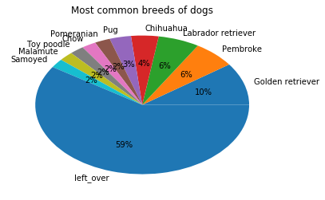

```python
# plot most common breed of dog by percentage
plt.pie(total_top_10, labels = total_top_10.index, autopct='%1.0f%%')
plt.title('Most common breeds of dogs')
```

### The average dog score rating

```python
#count rating numerator
master_archive.rating_numerator.value_counts()
```

```
12      500
10      442
11      426
13      307
9       156
8        98
7        54
14       43
5        36
6        32
3        19
4        17
2         9
1         8
420       2
```

[output cut: 26 more lines]

```python
# check for average ratings of top 10 breeds
master_archive.groupby("prediction_1")['rating_numerator'].mean().nlargest(10)
```

```
prediction_1
Clumber                        27.000000
West highland white terrier    17.454545
Borzoi                         16.500000
Soft-coated wheaten terrier    15.900000
Great pyrenees                 15.153846
Labrador retriever             14.773333
Siberian husky                 13.647059
Golden retriever               13.478992
Saluki                         12.500000
Briard                         12.333333
Name: rating_numerator, dtype: float64
```

```python
# Check for average ratings of least 10 breeds
master_archive.groupby("prediction_1")['rating_numerator'].mean().nsmallest(10)
```

```
prediction_1
Japanese spaniel          5.000000
Afghan hound              8.000000
Boston bull               8.666667
Appenzeller               9.000000
Ibizan hound              9.000000
Norwich terrier           9.000000
Scotch terrier            9.000000
Walker hound              9.000000
Welsh springer spaniel    9.000000
Maltese dog               9.066667
Name: rating_numerator, dtype: float64
```

```
Text(0,0.5,'Average Rating')
```

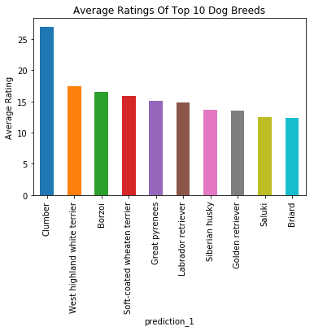

```python
master_archive.groupby("prediction_1")['rating_numerator'].mean().nlargest(10).plot(kind= 'bar');
plt.title('Average Ratings Of Top 10 Dog Breeds');
plt.ylabel('Average Rating')
```

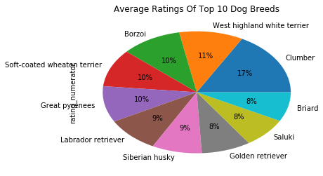

```python
# view the percentage
master_archive.groupby("prediction_1")['rating_numerator'].mean().nlargest(10).plot(kind= 'pie', autopct='%1.0f%%')
plt.title('Average Ratings Of Top 10 Dog Breeds');
```

```python
# score of all dogs
master_archive.rating_numerator.mean()
```

```
13.215172413793104
```

```python
# true dogs only
master_archive['rating_numerator'] = master_archive['rating_numerator'].astype('float')
```

```python
# mean for true dogs only
master_archive.loc[master_archive['1st_dog'] == True]['rating_numerator'].mean()
```

```
11.587697423108894
```

```python
# create a division row for rating numerator and denominator
master_archive['division'] = master_archive['rating_numerator'] / master_archive['rating_denominator']
```

```python
# check for the mean of all ratings
master_archive['division'].mean()
```

```
inf
```

```python
# check for the mean of only dogs ratings
master_archive.loc[master_archive['1st_dog'] == True]['division'].mean()
```

```
1.097378847254159
```

### The most common dog name

```python
# Find the total occurrences of top 12 dog names
master_archive.name.value_counts().nlargest(10)
```

```
Charlie    11
Lucy       11
Oliver     10
Cooper     10
Penny       9
Tucker      9
Lola        8
Sadie       8
The         8
Winston     8
Name: name, dtype: int64
```

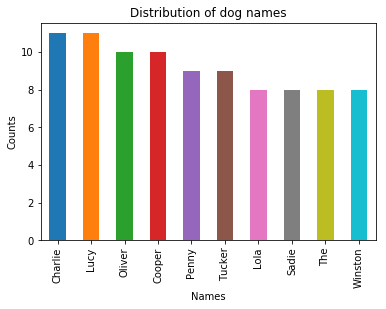

```python
# Plot the top 10 Dog names
plot(figsize=(12, 12))
master_archive.name.value_counts().nlargest(10).plot(kind = 'bar');
plt.title('Distribution of dog names');
plt.xlabel('Names');
plt.ylabel('Counts');
```

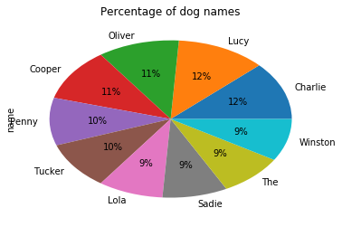

```python
# Plot the top 10 Dog names by percentage
master_archive.name.value_counts().nlargest(10).plot(kind = 'pie', autopct='%1.0f%%');
plt.title('Percentage of dog names');
```

Charlie and Lucy are the top most name given to dogs generally, followed by Oliver and cooper

### The most common dog breed prediction(confidence)

```python
# 10 top most frequent 1st prediction of dog breeds
master_archive.prediction_1.value_counts().nlargest(10)
```

```
Golden retriever      119
Pembroke               77
Labrador retriever     75
Chihuahua              50
Pug                    39
Pomeranian             28
Chow                   26
Toy poodle             26
Malamute               26
Samoyed                25
Name: prediction_1, dtype: int64
```

```python
# mean of p1 confidence
master_archive.confidence_1.mean()
```

```
0.62798212967581057
```

```python
# 10 topmost frequent 2nd prediction of dog
master_archive.prediction_2.value_counts().nlargest(10)
```

```
Labrador retriever          70
Cardigan                    63
Golden retriever            54
Chihuahua                   32
French bulldog              30
Siberian husky              30
Chesapeake bay retriever    30
Pomeranian                  27
Beagle                      27
Miniature poodle            26
Name: prediction_2, dtype: int64
```

```python
# mean of p2 confidence
master_archive.confidence_2.mean()
```

```
0.1430124671364921
```

```python
# 10 topmost frequent 3rd prediction of dog
master_archive.prediction_3.value_counts().nlargest(10)
```

```
Labrador retriever           62
Chihuahua                    48
Golden retriever             33
Eskimo dog                   31
Kelpie                       28
Staffordshire bullterrier    27
Pekinese                     26
Kuvasz                       25
Cocker spaniel               25
Beagle                       24
Name: prediction_3, dtype: int64
```

```python
# mean of p3 confidence
master_archive.confidence_3.mean()
```

```
0.061224308544438902
```